# Network Inference with sparse GGM - Correction

julien.chiquet@gmail.com, guillem.rigaill@gmail.com

Exposome Advanced 2018, London

This practical aims to provide a quick overview of sparse Gaussian Graphical Models (GGM) and their use in the context of network reconstruction for gene interaction networks.

To this end, we rely on the `R`-package **huge**, which implements some of the most popular sparse GGM methods and provides a set of basic tools for their handling and their analysis.

The first part focuses on an empirical analysis of the statistical models used for network reconstruction. The objective is to quickly study the range of applicability of these methods. It should also give you some insights about their limitations, especially toward the interpretability of the inferred network in terms of biology.

*Note* : you can form small and balanced groups of students to work. Some function required during the session are available in file `external_functions.R` (ask the teachers).

# First part: empirical study of sparse GGM

Load the **huge** package. Have a quick glance at the help.

## Synthetic data generation, Network representation

The function `huge.generator` allows to generate a random network and some (expression) data associated with this network.

- Use this function to generate a simple random network with the size of your choice. Have a look at the structure of the `R` object produced by the function.

```r
n <- 50; d <- 100
random.net  <- huge.generator(n, d, graph="random")
```

```
## Generating data from the multivariate normal distribution with the random graph structure....done.
```

```r
str(random.net, max.level = 1)
```

```
## List of 7
##  $ data      : num [1:50, 1:100] 0.65 1.446 -1.028 1.074 0.131 ...
##   ..- attr(*, "dimnames")=List of 2
##  $ sigma     : num [1:100, 1:100] 1 0.01545 -0.03478 -0.00433 0.01129 ...
##  $ sigmahat  : num [1:100, 1:100] 1 0.00731 0.08636 -0.00712 0.01259 ...
##  $ omega     : num [1:100, 1:100] 1.23 4.54e-18 -6.48e-18 -1.12e-18 5.67e-18 ...
##  $ theta     :Formal class 'dsCMatrix' [package "Matrix"] with 7 slots
##  $ sparsity  : num 0.0309
##  $ graph.type: chr "random"
##  - attr(*, "class")= chr "sim"
```

- Try different network typologies and plot the outputs with the dedicated `plot` function. Comment and explain what represent the different graphical outputs.

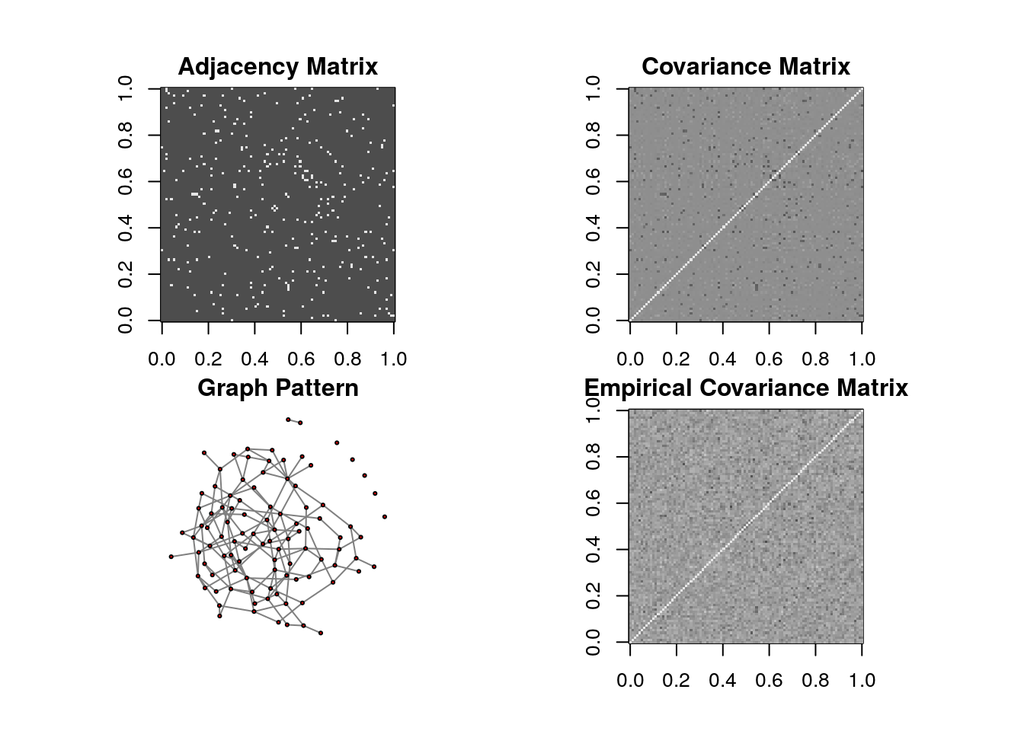

```r
plot(random.net)
```

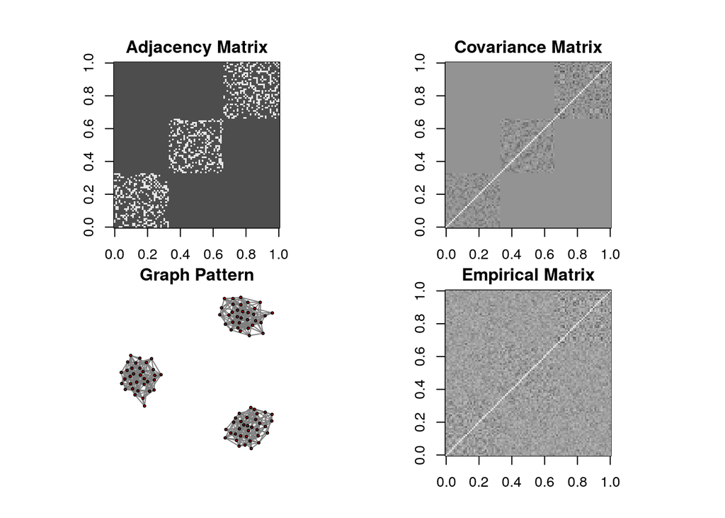

```r
cluster.net <- huge.generator(n, d, g = 3, graph="cluster", vis=TRUE, verbose=FALSE)
```

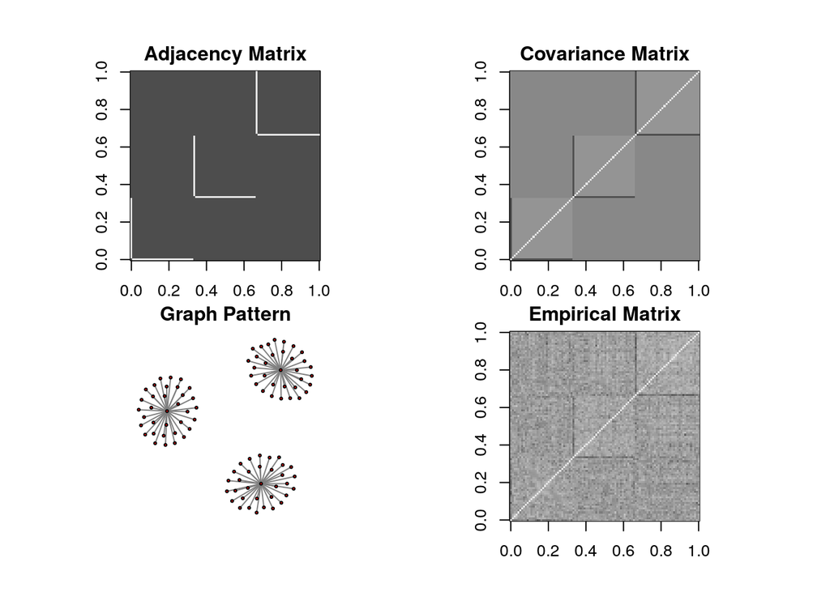

```r
hub.net <- huge.generator(n, d, g = 3, graph="hub", vis=TRUE, verbose=FALSE)
```

- Have a look at the distribution of the data generated. You may use `hist`, `density`, `qqnorm` and so on. Comment.

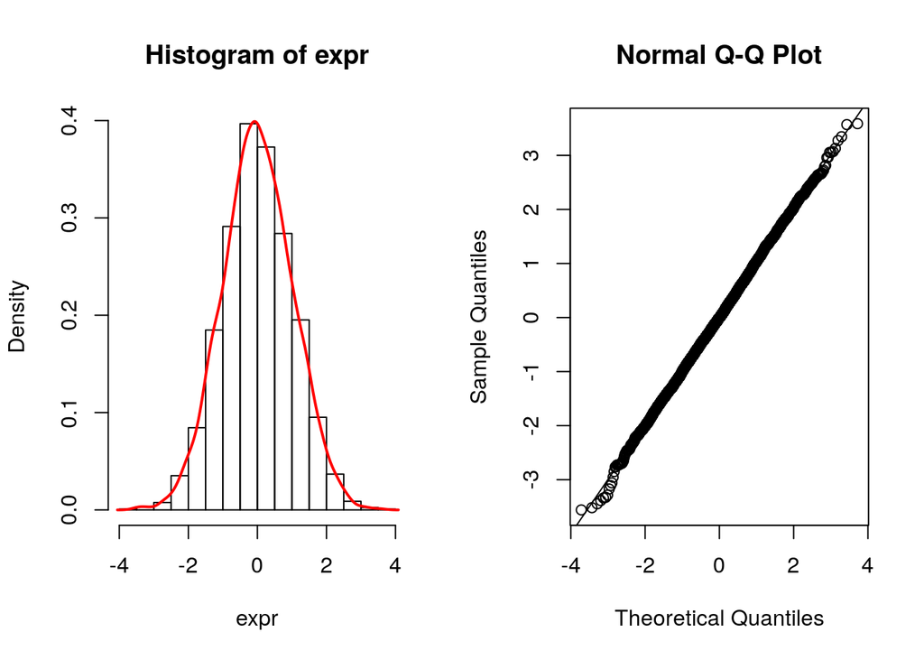

```r
expr <- random.net$data
par(mfrow=c(1,2))
hist(expr, probability = TRUE)
lines(density(expr), col="red", lwd=2)
qqnorm(expr); qqline(expr)
```

Real life is (hopefully) not that easy.

- How can you change the level of difficulty in the problem of network reconstruction?

## Correlation vs. Partial correlation

This section aims to illustrate the difference of relationship modeled by *correlation* and *partial correlation*.

- generate a graph with $d=10$ nodes, a single hub, and expression data with $n=200$ samples. We are going to study the statistical relationship between the hub (first node in your graph) and 2 of its neighbors. We call `hub` the index of the hub and `neighbor1`, `neighbor2` the label (index) of these three nodes.

```r
set.seed(1)
exp <- huge.generator(n=200, d=10, grap="hub",verbose=FALSE)
hub <- 1
neighbors <- which(exp$theta[, hub] != 0)
neighbor1 <- neighbors[1]; neighbor2 <- neighbors[2]
```

- Adjust three simple linear regressions between the data associated with these three nodes, that is, between `hub` and `neighbor1`, `hub` and `neighbor2`, and `neighbor1` and `neighbor2`. Use the function `lm` + `summary` to test the significance of each model. Comment.

```r
## all significant correlations
summary(lm(exp$data[, hub]~exp$data[, neighbor1]))
```

```
##
## Call:
## lm(formula = exp$data[, hub] ~ exp$data[, neighbor1])
##
## Residuals:
##      Min       1Q   Median       3Q      Max
## -2.62573 -0.62038  0.01327  0.52993  2.50639
##
## Coefficients:
##                       Estimate Std. Error t value Pr(>|t|)
## (Intercept)            0.04618    0.06820   0.677    0.499
## exp$data[, neighbor1] -0.35470    0.06456  -5.494  1.2e-07 ***
## ---
## Signif. codes:  0 '***' 0.001 '**' 0.01 '*' 0.05 '.' 0.1 ' ' 1
##
## Residual standard error: 0.9645 on 198 degrees of freedom
## Multiple R-squared:  0.1323, Adjusted R-squared:  0.1279
## F-statistic: 30.19 on 1 and 198 DF,  p-value: 1.196e-07
```

```r
summary(lm(exp$data[, hub]~exp$data[, neighbor2]))
```

```
##
## Call:
## lm(formula = exp$data[, hub] ~ exp$data[, neighbor2])
##
## Residuals:
##      Min       1Q   Median       3Q      Max
## -2.26976 -0.61419 -0.02027  0.59983  2.22808
##
## Coefficients:
##                       Estimate Std. Error t value Pr(>|t|)
## (Intercept)            0.04358    0.06257   0.697    0.487
## exp$data[, neighbor2] -0.54373    0.06358  -8.551 3.29e-15 ***
## ---
## Signif. codes:  0 '***' 0.001 '**' 0.01 '*' 0.05 '.' 0.1 ' ' 1
##
## Residual standard error: 0.8848 on 198 degrees of freedom
## Multiple R-squared:  0.2697, Adjusted R-squared:  0.266
## F-statistic: 73.13 on 1 and 198 DF,  p-value: 3.294e-15
```

```r
summary(lm(exp$data[, neighbor1]~exp$data[, neighbor2]))
```

```
##
## Call:
## lm(formula = exp$data[, neighbor1] ~ exp$data[, neighbor2])
##
## Residuals:
##      Min       1Q   Median       3Q      Max
## -2.93658 -0.68953 -0.02216  0.64551  2.96591
##
## Coefficients:
##                       Estimate Std. Error t value Pr(>|t|)
## (Intercept)           -0.00501    0.07327  -0.068  0.94556
## exp$data[, neighbor2]  0.23474    0.07445   3.153  0.00187 **
## ---
## Signif. codes:  0 '***' 0.001 '**' 0.01 '*' 0.05 '.' 0.1 ' ' 1
##
## Residual standard error: 1.036 on 198 degrees of freedom
## Multiple R-squared:  0.04781,    Adjusted R-squared:  0.043
## F-statistic: 9.941 on 1 and 198 DF,  p-value: 0.001868
```

This experiment shows that the expression of the neighbors are potentially correlated, although there is no direct link between them. As will be seen, partial correlation avoid such a spurious interaction.

- Partial correlation corresponds to correlation that remains between pairs of variables once remove the effect of the others variables. To test direct relationships between two neighbors, with thus have to remove the effect of all others variables. To do so, adjust two multiple linear model to predict the expression of the two neighbors by all the others genes but them.

```r
lm1 <- lm(exp$data[,neighbor1]~exp$data[,-c(neighbor1,neighbor2)])
lm2 <- lm(exp$data[,neighbor2]~exp$data[,-c(neighbor1,neighbor2)])
```

- Get back the residuals associated with each model. This corresponds to what is not predicted in the expression of each neighbor by all the genes but `neighbor1` and `neighbor2`.

```r
neighbor1.res <- residuals(lm1)
neighbor2.res <- residuals(lm2)
```

- Adjust simple linear regression between the residuals and test the significance of this model. Comment

```r
## no significant partial correlation
summary(lm(neighbor1.res~neighbor2.res))
```

```
##
## Call:
## lm(formula = neighbor1.res ~ neighbor2.res)
##
## Residuals:
##     Min      1Q  Median      3Q     Max
## -2.9372 -0.6478  0.0019  0.5966  2.7740
##
## Coefficients:
##                 Estimate Std. Error t value Pr(>|t|)
## (Intercept)   -2.722e-17  6.917e-02   0.000    1.000
## neighbor2.res  2.548e-02  8.367e-02   0.304    0.761
##
## Residual standard error: 0.9782 on 198 degrees of freedom
## Multiple R-squared:  0.000468,   Adjusted R-squared:  -0.00458
## F-statistic: 0.0927 on 1 and 198 DF,  p-value: 0.7611
```

- Use the `geom_smooth` function in the package `ggplot2` to adjust and represent the four simple linear regression models fitted so far and summary your experiment.

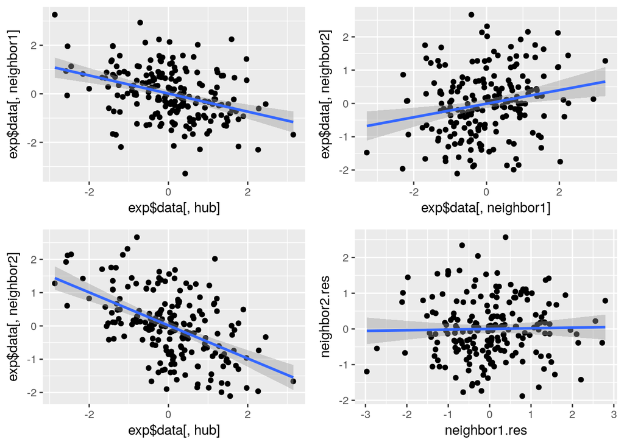

```r
multiplot(qplot(exp$data[, hub], exp$data[, neighbor1], geom="point") + geom_smooth(method="lm"),
          qplot(exp$data[, hub], exp$data[, neighbor2], geom="point") + geom_smooth(method="lm"),
          qplot(exp$data[, neighbor1], exp$data[, neighbor2], geom="point") + geom_smooth(method="lm"),
          qplot(neighbor1.res,neighbor2.res, geom="point") + geom_smooth(method="lm"), cols = 2)
```

### Network inference accuracy

Now, to the network reconstruction at last ! The function `huge` automatically select the most significant partial correlation between variables, by adjusting a sparse GGM to the data. The final number of interactions (i.e., the number of edge in the reconstructed network) is controlled by a tuning parameter, the choice of which can be obtained by cross-validation.

We want to study the effect of the sample size on the performance of two methods: the sparse GGM approach (hereafter `glasso`) and the simple correlation approach, which just consists in thresholding the matrix of empirical correlations.

- The following function `one.simu` performs a simulation by computing the area under ROC curve for the `glasso` and the `correlation` based approach from a data set generated with the `huge.generator` function. The number of genes is 25, and the sample size varies from 5 to 500. Read it, try to understand it…

```r
require(reshape2)
one.simu <- function(i) {
  cat("n =")
  d <- 25; seq.n <- c(5,15,30,50,100,250,500)
  out <- data.frame(t(sapply(seq.n, function(n) {
      cat("",n)
      exp <- huge.generator(n, d, verbose=FALSE)
      glasso <- huge(exp$data, method="glasso", verbose=FALSE)
      corthr <- huge(exp$data, method="ct", verbose=FALSE)
      res.corthr <- perf.auc(perf.roc(corthr$path, exp$theta))
      res.glasso <- perf.auc(perf.roc(glasso$path, exp$theta))
      return(setNames(c(res.glasso,res.corthr,n,i),
                      c("glasso","correlation","sample size", "simu")))
    })))
  return(melt(out, measure.vars = 1:2, value.name = "score"))
}
```

- Use this function to perform one single simulation and represent the evolution of the AUC for each method as a function of the sample size.

```r
out <- one.simu(1)
```

```
## n = 5 15 30 50 100 250 500
```

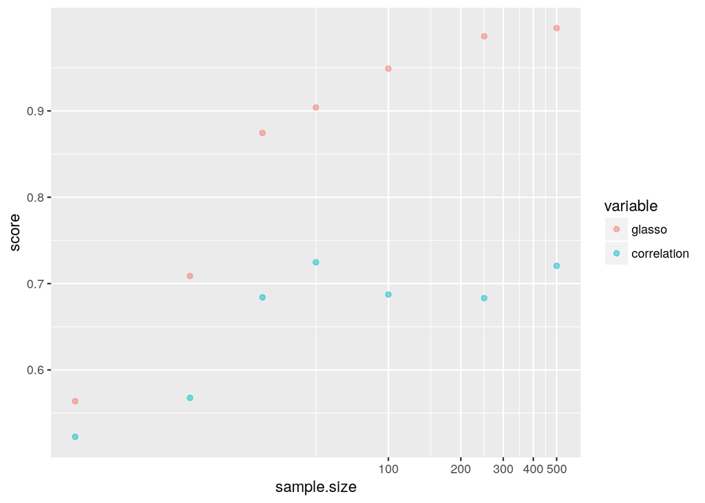

```r
ggplot(out, aes(x=sample.size, y=score,group=variable,colour=variable)) +
  geom_point(alpha=.5) + coord_trans(x="log10")
```

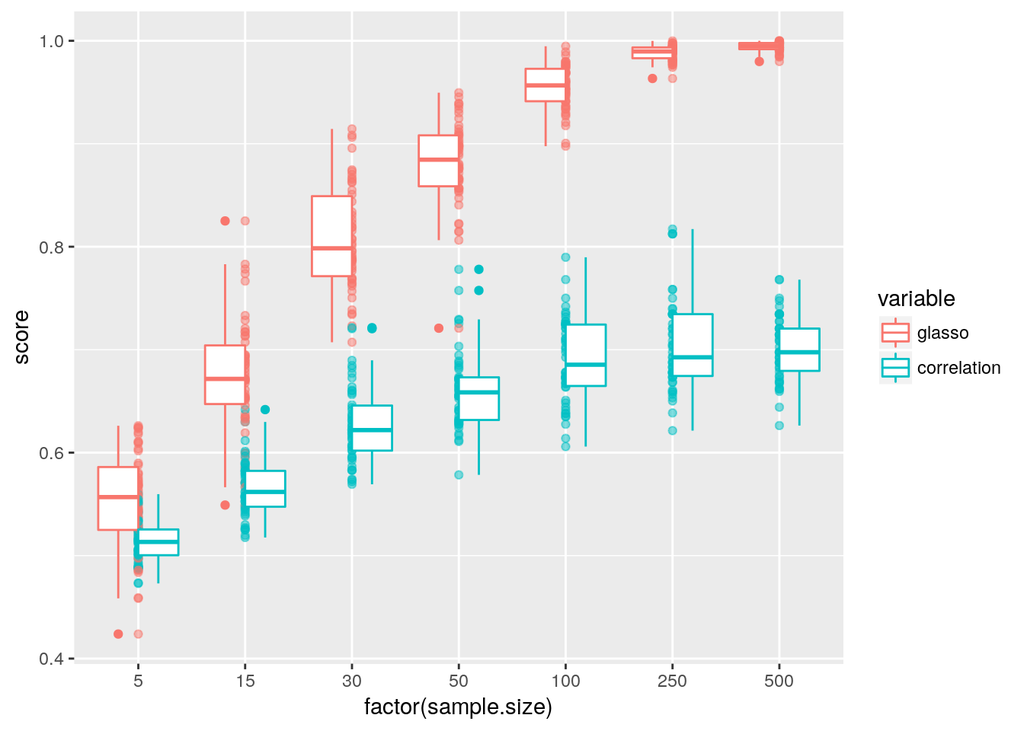

```r
library(parallel)
res <- do.call(rbind, mclapply(1:50, one.simu))
ggplot(res, aes(x=factor(sample.size), y=score)) +
  geom_point(alpha=.5, aes(group=variable,colour=variable)) +
  geom_boxplot(aes(colour=variable))
```

# Second part: transcriptomic data analysis

## Inferring a network from transcriptomic data, normalization?

Now we will have look at the gene expression levels of 16 genes part of the core network identified by Françoise Monéger and her colleagues. In total we have 20 measurements : 2 times 10 biological replicates of flower bud.

First, load the data and the network identified by Françoise Monéger and colleagues. (the network is store as 16 x 16 contingency matrix).

```r
load( file="data_school/Expr.RData")
load(file="data_school/Netw_FM.RData")
```

Then load a few usufull functions

```r
### Inference
source("external_functions.R")
require(huge)
### a simple function thresholding a matrix for nlambda values
### between the min and max value (outside of the diagonal)
cor.thres <- function(C.mat){
  diag(C.mat) <- 0
  C.mat <- abs(C.mat)
  lvls <- c(0, unique(C.mat), max(C.mat)+1)
  res <- lapply( lvls,
        FUN=function(thres) ((C.mat >= thres)+0))
}
```

### Inferring the network with sparse GGM or correlation network

Infer the network using correlation or glasso and draw the ROC of the two approaches.

```r
## pearson correlation approach
res.cor <- cor.thres(cor(X))
```

```r
## glasso and grid of lambda
min.lbd <- 100
lambdas <- rev(1/min.lbd * 10^seq(0, log10(min.lbd), length.out=1000))
res.glasso <- huge((X), method="glasso", lambda=lambdas, verbose=F)
```

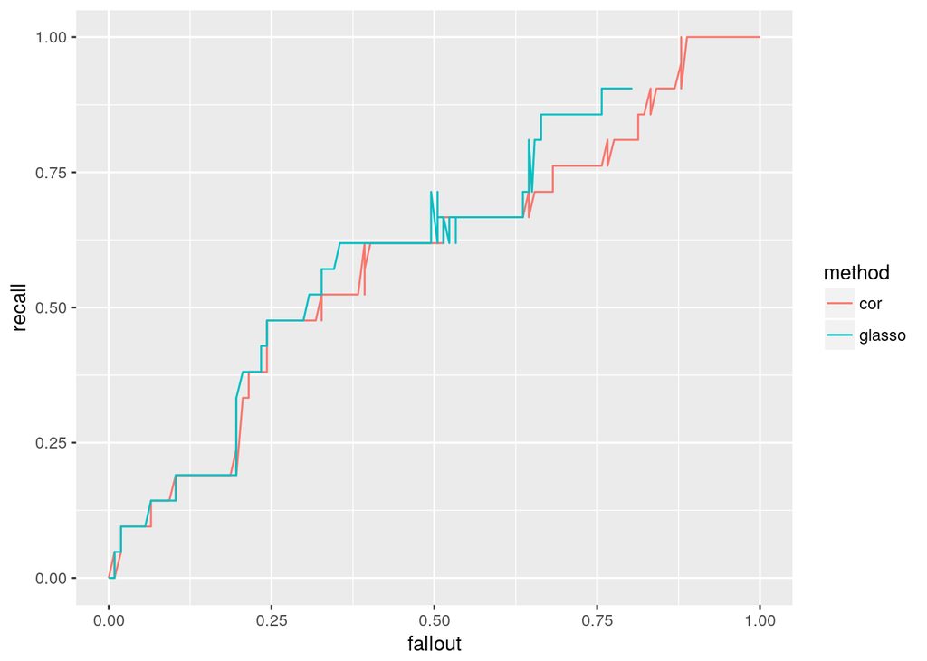

```r
## computing the roc curve
roc.cor <- perf.roc(res.cor, trueNetMat)
roc.glasso <- perf.roc(res.glasso$path, trueNetMat)

roc.cor$method <- "cor"
roc.glasso$method <- "glasso"

## plotting
require(ggplot2)
data <- rbind(roc.cor, roc.glasso)
p <- ggplot(data, aes(x=fallout, y=recall, group=method)) +
    geom_line(aes(colour = method))
p
```

### Normalisation and network inference

The huge package provides various way to pre-process the data (and try to make them more “normal”). Try to use the “skeptic” approach (`huge.npn(X,npn.func="skeptic")`) and draw its ROC curve. What do you conclude ?

```r
Q=(huge.npn(X, npn.func="skeptic"))
```

```
## Conducting nonparanormal (npn) transformation via skeptic....done.
```

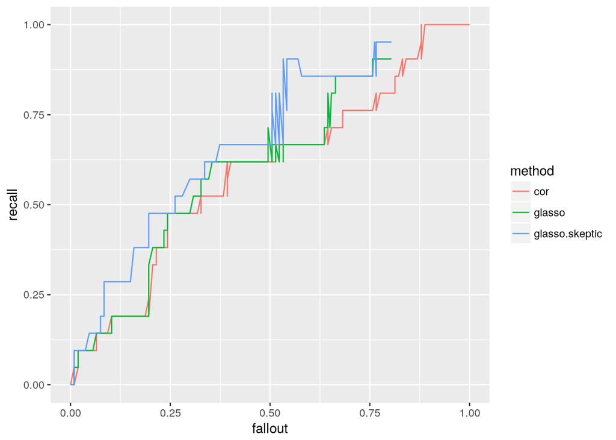

Glasso, Correlation and Glasso+skeptic

```r
min.lbd <- 100
lambdas <- rev(1/min.lbd * 10^seq(0, log10(min.lbd), length.out=1000))
res.glasso.skeptic <- huge(Q,
    method="glasso", lambda=lambdas, verbose=F)
roc.glasso.skeptic <- perf.roc(res.glasso.skeptic$path, trueNetMat)
roc.glasso.skeptic$method <- "glasso.skeptic"

## plotting
data <- rbind(roc.cor, roc.glasso, roc.glasso.skeptic)
p <- ggplot(data, aes(x=fallout, y=recall, group=method)) +
    geom_line(aes(colour = method))
p
```

### Inversion correlation ?

Given the number of samples we could also try to inverse the correlation matrix directly. Try this other approach and draw its ROC curve and conclude.

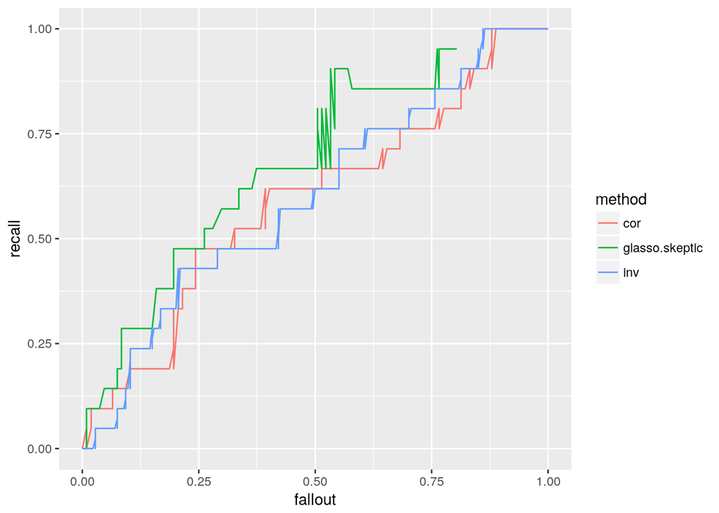

Correlation and inverse correlation

```r
res.inv <- cor.thres(solve(cor(X)))
roc.inv <- perf.roc(res.inv, trueNetMat)
roc.inv$method <- "inv"

## plotting
data <- rbind(roc.cor, roc.inv, roc.glasso.skeptic)
p <- ggplot(data, aes(x=fallout, y=recall, group=method)) +
    geom_line(aes(colour = method))
p
```

## Differential analysis and gene networks

Now we will look at some data from Guedj et al. (2011). In this data there are two groups ER positive breast tumors and ER negative breast tumors. A number of genes are differentially expressed between these two groups.

We will first load the data

```r
load ("data_school/breast_cancer_guedj11.RData") # raw data
load ("data_school/gen_name.RData") # each row of the raw data matrix is a gene.
gene.name <- unlist(gene.name)
data.raw <- expr
```

### Differential analysis

Run limma or a t.test analysis to compare the two groups. Assess the number of significant genes (with an adjusted p-value below 0.05).

```r
## limma analysis
require(limma)
```

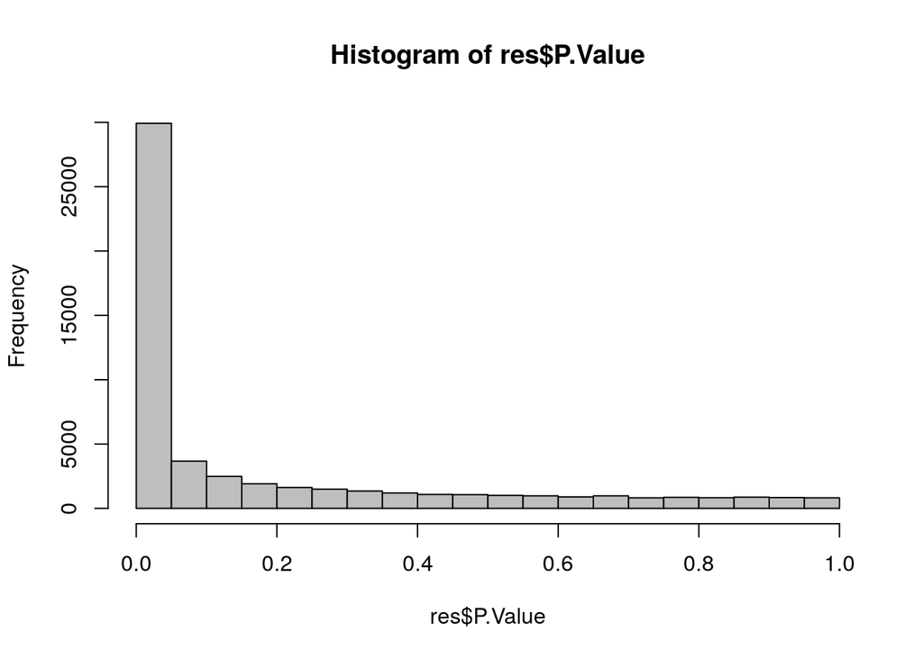

```r
design <- cbind(Moy=1, Erp=(class.ER == "ERp")+0)
fit <- lmFit(data.raw, design=design)
fit <- eBayes(fit)
res <- topTable(fit, coef="Erp", number=10^5, genelist=fit$genes, adjust.method="BH",
              sort.by="none", resort.by=NULL, p.value=1, lfc=0, confint=FALSE)

## checking the distribution of p-values
hist(res$P.Value, breaks=30, col="grey")
```

```r
## a lot of differentially expressed genes
sum(res$adj.P.Val <= 0.05)
```

```
## [1] 26661
```

```r
sum(res$adj.P.Val <= 10^-10)
```

```
## [1] 1840
```

### Network inference

Infer a network for each group using the first p=100 most differentially expressed genes. Check the shape of the ebic to assess the quality of the inference and the grid of lambdas.

```r
min.lbd <- 100
lambdas <- rev(1/min.lbd * 10^seq(0, log10(min.lbd), length.out=100))
selected_gene <- order(res$P.Value)[1:100] ## top 100 genes from diff analysis
require(huge)

data.ERm <- t(data.raw[selected_gene, which(class.ER=="ERm")])
data.ERp <- t(data.raw[selected_gene, which(class.ER=="ERp")])

gl.ERm <- huge(data.ERm, method="glasso", lambda=lambdas, verbose=F)
gl.ERp <- huge(data.ERp, method="glasso", lambda=lambdas, verbose=F)
sel.ERm <- huge.select(gl.ERm)
```

```
## Conducting extended Bayesian information criterion (ebic) selection....done
```

```r
sel.ERp <- huge.select(gl.ERp)
```

```
## Conducting extended Bayesian information criterion (ebic) selection....done
```

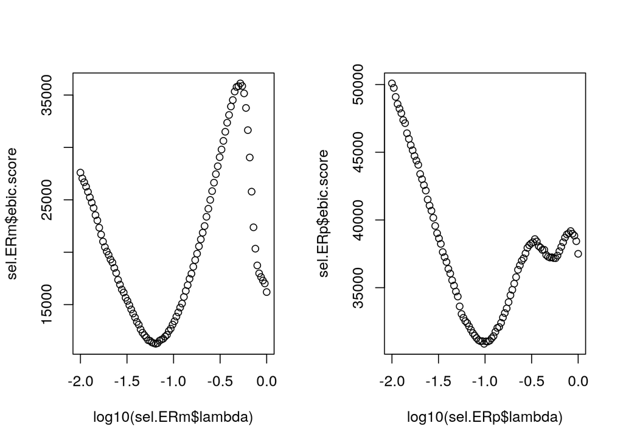

```r
### check bic curve to know how many genes to take
par(mfrow=c(1,2))
plot(log10(sel.ERm$lambda), sel.ERm$ebic.score)
plot(log10(sel.ERp$lambda),sel.ERp$ebic.score)
```

### ESR1 edges in ER positive tumors

Identify ESR1 edges that are only present in ER positive tumors.

```r
## ESR1 is the first gene
toLookAt <- which(sel.ERp$refit[1, ] ==1 & sel.ERm$refit[1,] ==0)
output.test <- data.frame(name=gene.name[selected_gene][toLookAt],
icov = sel.ERp$opt.icov[1, toLookAt],
logFC = res$logFC[selected_gene][toLookAt],
pvalue= res$P.Value[selected_gene][toLookAt]
)

for(i in 2:4) output.test[, i] <- signif(output.test[, i], 3)
output.test
```

```
##                  name     icov  logFC   pvalue
## 215867_x_at      CA12 -0.00161  2.050 5.42e-52
## 204667_at       FOXA1 -0.15700  1.650 1.63e-39
## 200670_at        XBP1 -0.02750  0.930 1.44e-36
## 226506_at       THSD4 -0.08220  1.110 4.33e-33
## 205355_at      ACADSB -0.00692  1.220 5.74e-33
## 204798_at         MYB -0.17600  1.340 4.40e-31
## 220559_at         EN1  0.06660 -1.280 9.75e-30
## 227262_at      HAPLN3  0.11200 -0.499 8.36e-29
## 226197_at          AR -0.04950  1.330 2.58e-28
## 200810_s_at     CIRBP  0.04760  0.604 4.00e-28
##             Not.Known -0.10100  0.982 6.84e-28
## 219497_s_at    BCL11A  0.05110 -1.310 1.34e-27
## 225911_at        NPNT -0.00380  1.490 4.85e-27
```

### Stability of those edges

Assess whether those edges are stable using resampling. Search “FOXA1” in google scholar or entrez.

```r
data.ERm <- t(data.raw[selected_gene, which(class.ER=="ERm")])
data.ERp <- t(data.raw[selected_gene, which(class.ER=="ERp")])

one.resample <- function(i_, prop=0.9){
##  print(i_)
  n.X <- nrow(data.ERm)
  n.Y <- nrow(data.ERp)
  X <- data.ERm[sample.int(n.X, size=trunc(0.9*n.X)), ]
  Y <- data.ERp[sample.int(n.Y, size=trunc(0.9*n.Y)), ]

  gl.ERm <- huge(X, method="glasso", nlambda=100, verbose=F)
  gl.ERp <- huge(Y, method="glasso", nlambda=100, verbose=F)
  sel.ERm <- huge.select(gl.ERm, verbose=F)
  sel.ERp <- huge.select(gl.ERp, verbose=F)
return(sel.ERp$refit[1, ] ==1 & sel.ERm$refit[1,] ==0)
}

require(parallel)
stability_res <- mclapply(1:100, FUN=one.resample, mc.cores=1)
proba.out <- rowMeans(do.call("cbind", stability_res))

toLookAt <- which(proba.out > 0.95)
output.test <- data.frame(name=gene.name[selected_gene][toLookAt],
icov = sel.ERp$opt.icov[1, toLookAt],
logFC = res$logFC[selected_gene][toLookAt],
pvalue= res$P.Value[selected_gene][toLookAt],
proba=proba.out[toLookAt]
)

for(i in 2:4) output.test[, i] <- signif(output.test[, i], 3)
output.test
```

```
##                  name    icov  logFC   pvalue proba
## 204667_at       FOXA1 -0.1570  1.650 1.63e-39  1.00
## 220559_at         EN1  0.0666 -1.280 9.75e-30  1.00
## 227262_at      HAPLN3  0.1120 -0.499 8.36e-29  0.99
## 226197_at          AR -0.0495  1.330 2.58e-28  0.99
##             Not.Known -0.1010  0.982 6.84e-28  1.00
## 219497_s_at    BCL11A  0.0511 -1.310 1.34e-27  1.00
```

### Correlation

Compute the correlation between ESR1 and the top 100 genes in ER positive and ER negative tumors. Look at FOXA1.

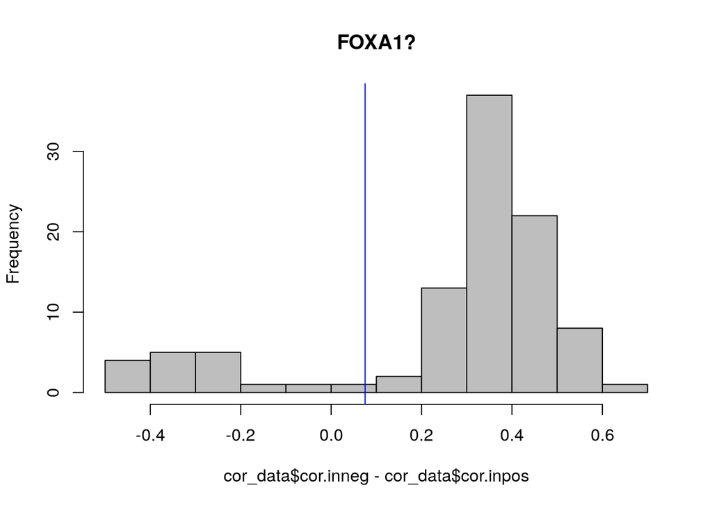

```r
## looking at the correlation
cor_data <- data.frame(name=gene.name[selected_gene],
cor.inneg = signif(cor(data.ERm)[1, ], 3),
cor.inpos = signif(cor(data.ERp)[1, ])
)

hist(cor_data$cor.inneg - cor_data$cor.inpos, col="grey", main="FOXA1?")
abline(v=cor_data$cor.inneg[13] - cor_data$cor.inpos[13], col="blue")
```